# CO2 Emission

Yuhan Xu, Christopher, Wentao Hu

11/13/2020

# Introduction

## Data set

The data set our group analyzed includes: carbon emissions (long-format) of each country from 1960 to 2018. Through the analysis of this data set, we can find out which countries have the largest carbon emissions, the annual changes in carbon emissions in these countries, the changes in global carbon emissions and etc.

# Summary

For our data set we decided to calculate 5 summary information. They are individually: The total net world carbon dioxide export, The highest most recent carbon export, The lowest most recent carbon export, the highest rate of carbon export growth, and the lowest rate of carbon export growth.(world_net_co2_export, co2_max_recent, co2_min_recent, co2_max_rate, co2_min_rate)

**world_net_co2_export:** 31772.33 The total net world carbon dioxide export

**co2_max_recent:** 9632.4621 The highest most recent carbon export

**co2_min_recent:** 0.069614 The lowest most recent carbon export

**co2_max_rate:** 166.0769328 The highest rate of carbon export growth

**co2_min_rate:** 0.0012002 The lowest rate of carbon export growth

# Table

| Country | Period of Years | Net CO2 Export | CO2 Export Rate |
| --- | --- | --- | --- |
| China | 58 | 9632.46 | 1.66e+02 |
| United.States.of.America | 58 | 3253.18 | 5.61e+01 |
| India | 58 | 2533.52 | 4.37e+01 |
| Russian.Federation | 58 | 1637.84 | 2.82e+01 |
| Japan | 58 | 1082.58 | 1.87e+01 |
| Iran | 58 | 683.91 | 1.18e+01 |
| South.Korea | 58 | 646.25 | 1.11e+01 |
| Saudi.Arabia | 58 | 630.39 | 1.09e+01 |
| Indonesia | 58 | 593.53 | 1.02e+01 |
| Ukraine | 58 | 506.87 | 8.74e+00 |
| Brazil | 58 | 477.04 | 8.22e+00 |
| Mexico | 58 | 433.25 | 7.47e+00 |
| Turkey | 58 | 411.38 | 7.09e+00 |
| South.Africa | 58 | 404.42 | 6.97e+00 |
| Canada | 58 | 402.02 | 6.93e+00 |
| Italy | 58 | 385.39 | 6.64e+00 |
| Germany | 58 | 358.88 | 6.19e+00 |
| Australia | 58 | 332.10 | 5.73e+00 |
| Spain | 58 | 319.19 | 5.50e+00 |
| Thailand | 58 | 284.52 | 4.91e+00 |
| United.Kingdom | 58 | 281.35 | 4.85e+00 |
| Poland | 58 | 264.16 | 4.55e+00 |
| Taiwan | 58 | 262.77 | 4.53e+00 |
| France | 58 | 258.92 | 4.46e+00 |
| Malaysia | 58 | 250.32 | 4.32e+00 |
| Kazakhstan | 58 | 228.54 | 3.94e+00 |
| United.Arab.Emirates | 58 | 222.97 | 3.84e+00 |
| Egypt | 58 | 222.78 | 3.84e+00 |
| Pakistan | 58 | 211.61 | 3.65e+00 |
| Vietnam | 58 | 199.18 | 3.43e+00 |

[output cut: 183 more lines]

The table above summarizes the information for our data set in descending order from the country with the highest net carbon export in the world to the lowest. in total it has 4 different columns(Name of the country, the duration by which data for carbon exports are recorded in years, the net carbon dioxide export of the country, and the rate of carbon export of each country by year) (country, period_of_years, net_co2_export, co2_export_rate) in order. The most pertinent observations are the rate of carbon emissions for a country like China and a country like Afghanistan. As there are two distinctions between these countries. One being a developing country and the other being an underdeveloped country. The large distinction in terms of their CO2 export rate by year is massive and it also indicates their economic standing and growth.

# Chart1

Currently, the United States is the country with the second highest carbon emissions in the world. We hope that by comparing the US carbon emissions and global carbon emissions data from 1960 to 2018, we can find the relationship between the two. Through the graph, we can find that before 2007, the US carbon emissions and global carbon emissions have both increased. But after 2007, carbon emissions in the United States showed a downward trend, while global carbon emissions continued to increase.

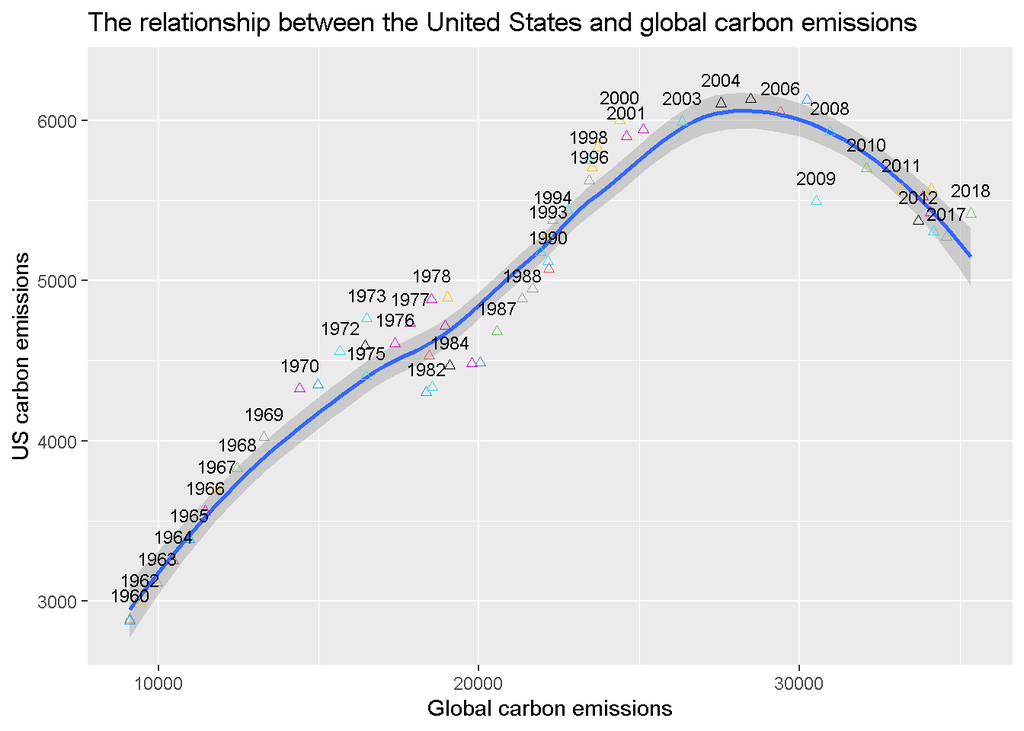

# Chart2

United States has the highest GDP in the world, We hope that by listing the US carbon emissions data from 1960 to 2018, we will find the carbon emissions trends of the world’s top countries. We can find that the carbon emissions in the United States have shown a downward trend after 2007. It can be speculated that after 2007, the economic center of the United States shifted to industries with low carbon emissions.

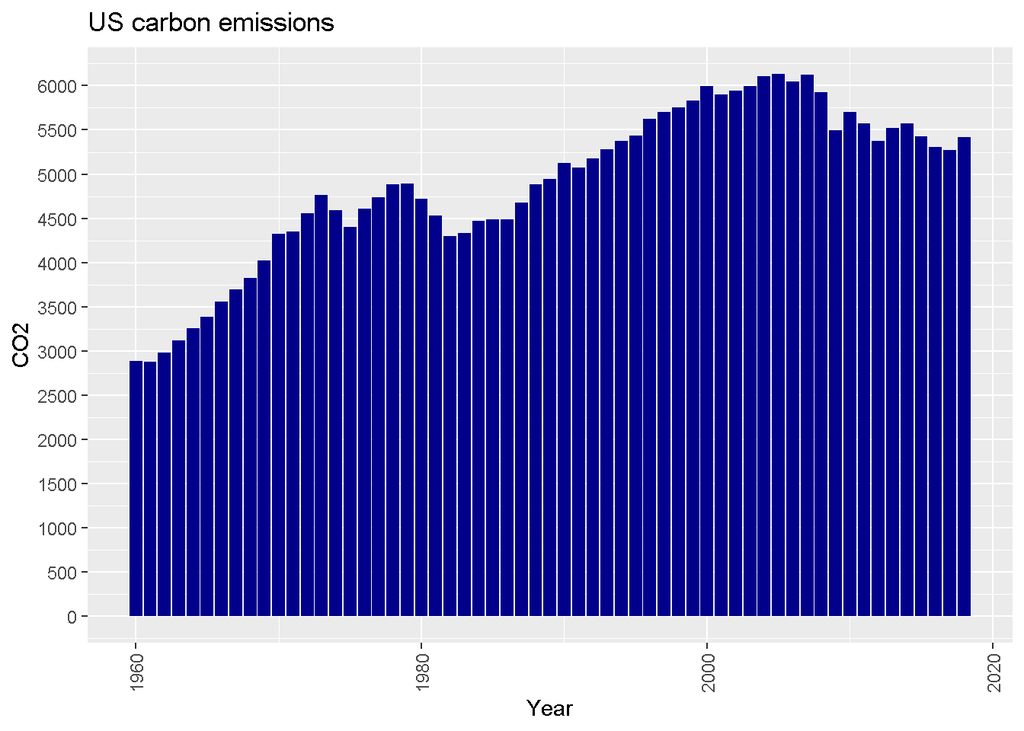

# Chart3

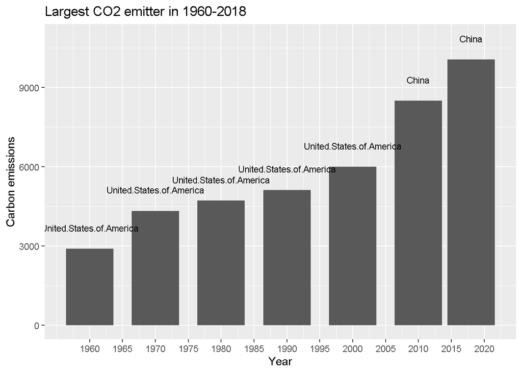